# PA1_template.Rmd

Juan Cano

17/9/2018

## Loading and preprocessing the data

### 1. Load the data

```r
setwd("~/Desktop/Coursera/5- Reproducible Research")
```

```r
activity<- read.csv("./data/activity.csv")
head(activity)
```

```
##   steps       date interval
## 1    NA 2012-10-01        0
## 2    NA 2012-10-01        5
## 3    NA 2012-10-01       10
## 4    NA 2012-10-01       15
## 5    NA 2012-10-01       20
## 6    NA 2012-10-01       25
```

```r
summary(activity)
```

```
##      steps                date          interval
##  Min.   :  0.00   2012-10-01:  288   Min.   :   0.0
##  1st Qu.:  0.00   2012-10-02:  288   1st Qu.: 588.8
##  Median :  0.00   2012-10-03:  288   Median :1177.5
##  Mean   : 37.38   2012-10-04:  288   Mean   :1177.5
##  3rd Qu.: 12.00   2012-10-05:  288   3rd Qu.:1766.2
##  Max.   :806.00   2012-10-06:  288   Max.   :2355.0
##  NA's   :2304     (Other)   :15840
```

### 2. Process/transform the data (if necessary) into a format suitable for your analysis

```r
activity$date<- as.Date(activity$date, format = "%Y-%m-%d")
activity2<- activity[!is.na(activity$steps),]
head(activity2)
```

```
##     steps       date interval
## 289     0 2012-10-02        0
## 290     0 2012-10-02        5
## 291     0 2012-10-02       10
## 292     0 2012-10-02       15
## 293     0 2012-10-02       20
## 294     0 2012-10-02       25
```

```r
summary(activity2)
```

```
##      steps             date               interval
##  Min.   :  0.00   Min.   :2012-10-02   Min.   :   0.0
##  1st Qu.:  0.00   1st Qu.:2012-10-16   1st Qu.: 588.8
##  Median :  0.00   Median :2012-10-29   Median :1177.5
##  Mean   : 37.38   Mean   :2012-10-30   Mean   :1177.5
##  3rd Qu.: 12.00   3rd Qu.:2012-11-16   3rd Qu.:1766.2
##  Max.   :806.00   Max.   :2012-11-29   Max.   :2355.0
```

## What is mean total number of steps taken per day?

Calculate the total number of steps taken per day:

```r
activity3<- group_by(activity2, date)
act3<-data.frame(summarise(activity3, sum(steps)))
head(act3)
```

```
##         date sum.steps.
## 1 2012-10-02        126
## 2 2012-10-03      11352
## 3 2012-10-04      12116
## 4 2012-10-05      13294
## 5 2012-10-06      15420
## 6 2012-10-07      11015
```

### 1. Make a histogram of the total number of steps taken each day

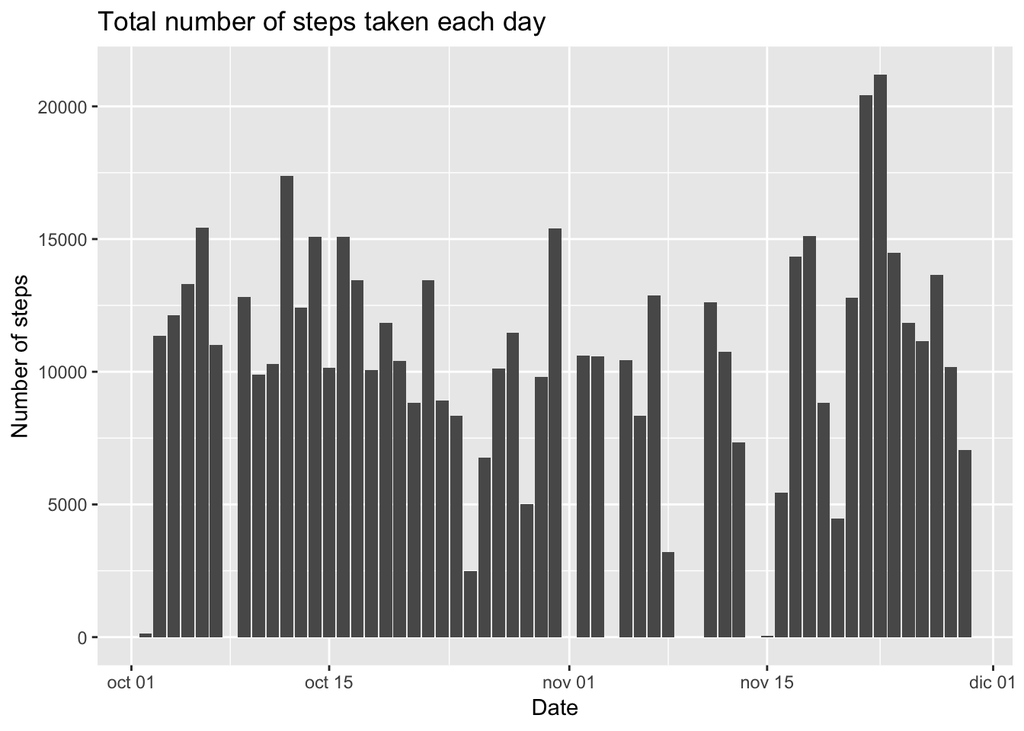

```r
ggplot(act3, (aes(x = date, y = sum.steps.))) +
        geom_bar(stat="identity") +
        labs(x = "Date",
             y = "Number of steps",
             title = "Total number of steps taken each day")
```

### 2. Calculate and report the mean and median total number of steps taken per day

```r
actMean<- mean(act3$sum.steps.)
actMean
```

```
## [1] 10766.19
```

```r
actMedian<- median(act3$sum.steps.)
actMedian
```

```
## [1] 10765
```

## What is the average daily activity pattern?

### 1. Make a time series plot of the 5-minute interval (x-axis) and the average number of steps taken, averaged across all days (y-axis)

```r
activity4<- data.frame(activity2$interval, activity2$steps)
interval<- group_by(activity4, activity2.interval)
act_interval<- data.frame(summarise(interval, mean(activity2.steps)))
head(act_interval)
```

```
##   activity2.interval mean.activity2.steps.
## 1                  0             1.7169811
## 2                  5             0.3396226
## 3                 10             0.1320755
## 4                 15             0.1509434
## 5                 20             0.0754717
## 6                 25             2.0943396
```

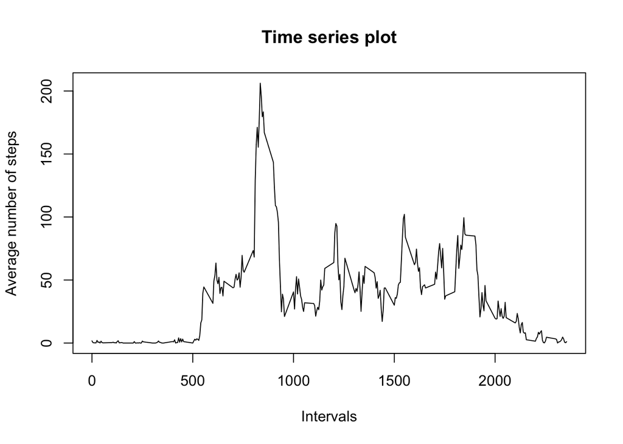

```r
plot(act_interval$activity2.interval, act_interval$mean.activity2.steps, type ="l", main= "Time series plot", xlab= "Intervals", ylab= "Average number of steps")
```

### 2.Which 5-minute interval, on average across all the days in the dataset, contains the maximum number of steps?

```r
max_interval<- which.max(act_interval$mean.activity2.steps)
max_interval
```

```
## [1] 104
```

```r
act_interval[104,1]
```

```
## [1] 835
```

On average across all the days in the dataset, the maximum number of steps is in the 8:35 5-minute interval, with a mean of 206.17 steps.

## Imputing missing values

### 1. Calculate and report the total number of missing values in the dataset

```r
sum(is.na(activity))
```

```
## [1] 2304
```

### 2. Devise a strategy for filling in all of the missing values in the dataset. The strategy does not need to be sophisticated. For example, you could use the mean/median for that day, or the mean for that 5-minute interval, etc.

We are going to use the mean for that 5-minute interval.

### 3. Create a new dataset that is equal to the original dataset but with the missing data filled in

```r
fillNA<- activity
for (i in 1:nrow(fillNA)){
        if (is.na(fillNA$steps[i])){
                fillNA$steps [i]<- act_interval[which(fillNA$interval [i] == act_interval$activity2.interval), ]$mean.activity2.steps.
        }
}

sum(is.na(fillNA))
```

```
## [1] 0
```

```r
head(fillNA)
```

```
##       steps       date interval
## 1 1.7169811 2012-10-01        0
## 2 0.3396226 2012-10-01        5
## 3 0.1320755 2012-10-01       10
## 4 0.1509434 2012-10-01       15
## 5 0.0754717 2012-10-01       20
## 6 2.0943396 2012-10-01       25
```

### 4. Make a histogram of the total number of steps taken each day and Calculate and report the mean and median total number of steps taken per day. Do these values differ from the estimates from the first part of the assignment? What is the impact of imputing missing data on the estimates of the total daily number of steps?

Total number of steps taken each day:

```r
activity_fill<- group_by(fillNA, date)
act_fill<-data.frame(summarise(activity_fill, sum(steps)))
head(act_fill)
```

```
##         date sum.steps.
## 1 2012-10-01   10766.19
## 2 2012-10-02     126.00
## 3 2012-10-03   11352.00
## 4 2012-10-04   12116.00
## 5 2012-10-05   13294.00
## 6 2012-10-06   15420.00
```

Histogram:

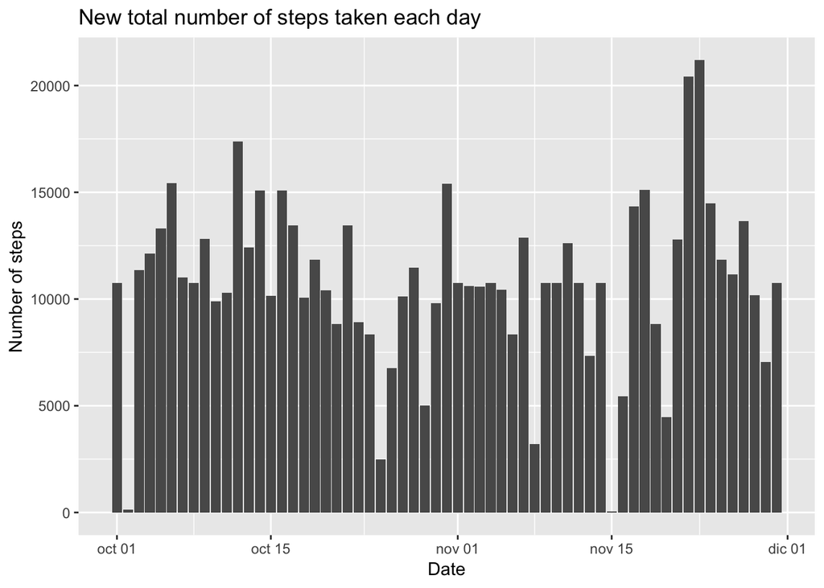

```r
ggplot(act_fill, (aes(x = date, y = sum.steps.))) +
        geom_bar(stat="identity") +
        labs(x = "Date",
             y = "Number of steps",
             title = "New total number of steps taken each day")
```

Calculate and report the mean and median total number of steps taken per day:

```r
actnewMean<- mean(act_fill$sum.steps.)
actnewMean
```

```
## [1] 10766.19
```

```r
actnewMedian<- median(act_fill$sum.steps.)
actnewMedian
```

```
## [1] 10766.19
```

## Are there differences in activity patterns between weekdays and weekends?

### 1. Create a new factor variable in the dataset with two levels – “weekday” and “weekend” indicating whether a given date is a weekday or weekend day.

```r
fillNA$days<- factor(format(as.Date(fillNA$date),"%A"))
levels(fillNA$days)
```

```
## [1] "domingo"   "jueves"    "lunes"     "martes"    "miércoles" "sábado"
## [7] "viernes"
```

```r
levels(fillNA$days)<- list(weekday = c("lunes", "martes", "miércoles", "jueves", "viernes"),
                        weekend = c("sábado", "domingo"))
levels(fillNA$days)
```

```
## [1] "weekday" "weekend"
```

### 2. Make a panel plot containing a time series plot (i.e. type = “l”) of the 5-minute interval (x-axis) and the average number of steps taken, averaged across all weekday days or weekend days (y-axis).

```r
avg_step_days<- aggregate(steps ~ interval + days, data=fillNA, FUN = "mean")
head(avg_step_days)
```

```
##   interval    days      steps
## 1        0 weekday 2.25115304
## 2        5 weekday 0.44528302
## 3       10 weekday 0.17316562
## 4       15 weekday 0.19790356
## 5       20 weekday 0.09895178
## 6       25 weekday 1.59035639
```

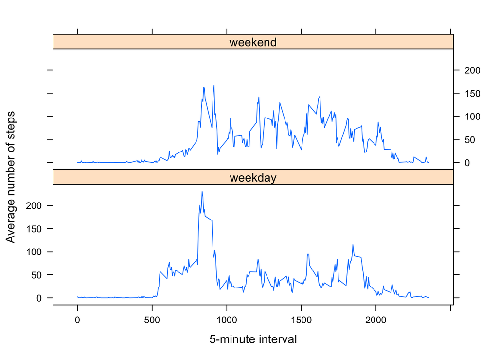

```r
xyplot(avg_step_days$steps ~ avg_step_days$interval | avg_step_days$days,
       layout = c(1, 2), type = "l",
       xlab = "5-minute interval", ylab = "Average number of steps")
```